# Course Project-Practical Machine Learning

Federico Di Marco

2022-08-11

## Overview

In this project data from accelerometers on the belt, forearm, arm, and dumbell of 6 participants are used to predict the quality of the exercise.

Four models are trained: -> Decision Tree -> Random Forest -> Gradient Boosted Trees -> Support Vector Machine

## Preparation

Loading libraries and data. Moreover, the seed is set to ensure the reprotusibility of the results.

```r
#Libraries
library(lattice)
library(ggplot2)
library(caret)
library(kernlab)
library(rattle)
library(corrplot)
#Data
traincsv <- read.csv("./data/pml-training.csv")
testcsv <- read.csv("./data/pml-testing.csv")

#Seed
set.seed(1234)
```

## Data Exploration and Cleaning

```r
head(traincsv)
```

```
##   X user_name raw_timestamp_part_1 raw_timestamp_part_2   cvtd_timestamp
## 1 1  carlitos           1323084231               788290 05/12/2011 11:23
## 2 2  carlitos           1323084231               808298 05/12/2011 11:23
## 3 3  carlitos           1323084231               820366 05/12/2011 11:23
## 4 4  carlitos           1323084232               120339 05/12/2011 11:23
## 5 5  carlitos           1323084232               196328 05/12/2011 11:23
## 6 6  carlitos           1323084232               304277 05/12/2011 11:23
##   new_window num_window roll_belt pitch_belt yaw_belt total_accel_belt
## 1         no         11      1.41       8.07    -94.4                3
## 2         no         11      1.41       8.07    -94.4                3
## 3         no         11      1.42       8.07    -94.4                3
## 4         no         12      1.48       8.05    -94.4                3
## 5         no         12      1.48       8.07    -94.4                3
## 6         no         12      1.45       8.06    -94.4                3
##   kurtosis_roll_belt kurtosis_picth_belt kurtosis_yaw_belt skewness_roll_belt
```

[output cut: 251 more lines]

The training set contains columns of NAs that can be removed. Moreover, the variable in the columns from 1 to 7 are irrelevant for the outcome and then they are removed.

```r
traincsv <- traincsv[,colSums(is.na(traincsv) | traincsv == "") < 100]
traincsv <- traincsv[,-c(1:7)]
```

## Train of the models

First of all let’s split the traincsv data in train and test data.

```r
inTrain <- createDataPartition(y=traincsv$classe, p=0.7, list=FALSE)
train <- traincsv[inTrain,]
test <- traincsv[-inTrain,]
```

# Decision Tree

Training:

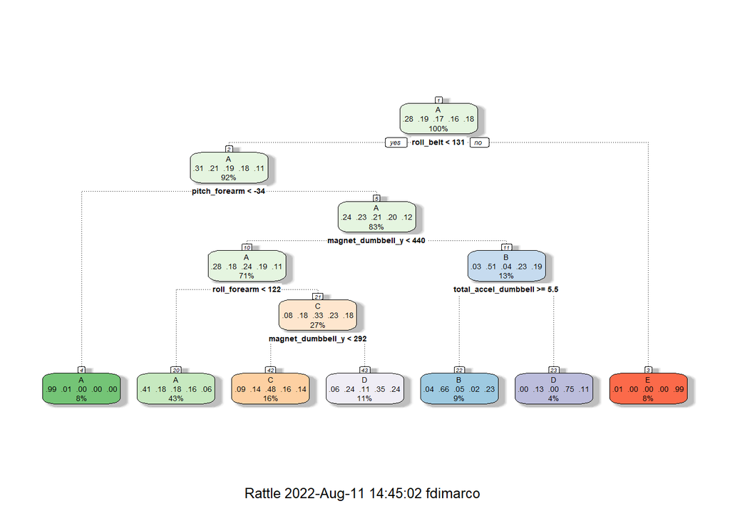

```r
control <- trainControl(method="cv", number=3, verboseIter=F)
mod_DT <- train(classe~., data=train, method="rpart", trControl = control, tuneLength = 5)
fancyRpartPlot(mod_DT$finalModel)
```

Prediction:

```r
pred_DT <- predict(mod_DT, test)
cmDT <- confusionMatrix(pred_DT, factor(test$classe))
print(paste('Decision Tree accuracy:',as.character(round(cmDT$overall[1],3))))
```

```
## [1] "Decision Tree accuracy: 0.537"
```

# Random Forest

Training:

```r
mod_RF <- train(classe~., data=train, method="rf", trControl = control, tuneLength = 5)
```

Prediction:

```r
pred_RF <- predict(mod_RF, test)
cmRF <- confusionMatrix(pred_RF, factor(test$classe))
print(paste('Random Forest accuracy:',as.character(round(cmRF$overall[1],3))))
```

```
## [1] "Random Forest accuracy: 0.996"
```

# Gradient Boosted Trees

Training:

```r
mod_GBM <- train(classe~., data=train, method="gbm", trControl = control, tuneLength = 5, verbose = FALSE)
```

Prediction:

```r
pred_GBM <- predict(mod_GBM, test)
cmGBM <- confusionMatrix(pred_GBM, factor(test$classe))
print(paste('Gradient Boosted Trees accuracy:',as.character(round(cmGBM$overall[1],3))))
```

```
## [1] "Gradient Boosted Trees accuracy: 0.992"
```

# Support Vector Machine

Training:

```r
mod_SVM <- train(classe~., data=train, method="svmLinear", trControl = control, tuneLength = 5, verbose = FALSE)
```

Prediction:

```r
pred_SVM <- predict(mod_SVM, test)
cmSVM <- confusionMatrix(pred_SVM, factor(test$classe))
print(paste('Support Vector Machine accuracy',as.character(round(cmSVM$overall[1],3))))
```

```
## [1] "Support Vector Machine accuracy 0.781"
```

# Prediction of the test set

In the previous analysis the best model turned out to be the random forest model and this is used for the predition of the test set.

```r
pred <- predict(mod_RF, testcsv)
print(pred)
```

```
##  [1] B A B A A E D B A A B C B A E E A B B B
## Levels: A B C D E
```